# Checking SLiM fixation probability of beneficial mutation - R Notebook

**Import libraries**

```r
library(tidyverse)
library(ggplot2)
```

**Loading data**

3 types of files contains information about the simulations :

- ../../parameters/SIM-ID/*_prior_parameters.txt
- ../../simulations/SIM-ID/*_sweep_parameters.txt
- ../../logs/SIM-ID/*_log.txt : contain one line for each failed SLiMulation.

**First Example**

First, as and example, we’ll have a look at the first file of the first log directory :

**Setup Path to Log files**

```r
# Set path to log folders
logPath = "../../logs/TESTING_FIX_PROBA/"

# Works on the first directory
logDir = list.dirs(logPath)[-1][1]

# Get list of all log files inside this specific folder
logFiles = list.files(logDir)
```

**Print List of all LogFiles of the first directory**

```r
print(logFiles)
```

**Load first file as a tibble and print it**

- *Note 1* : columns are converted into correct type.
- *Note* : columns are filtered to remove duplicate “header”.

```r
logFile = logFiles[1]

exampleLog <- as_tibble(read.table(paste(logDir, logFile, sep='/'), h=T)) %>% filter(sim_id!='sim_id')
exampleLog <- exampleLog %>% mutate(sim_id = as.factor(sim_id), outcome = as.factor(outcome), NeA = as.integer(NeA), NeB = as.integer(NeB), s = as.double(s),
                         r = as.double(r), mu = as.double(mu), L = as.integer(L), m = as.double(m), mut_pos = as.integer(mut_pos), rise_gen = as.integer(rise_gen), loss_gen = as.integer(loss_gen),
                         SLiM_gen = as.integer(SLiM_gen), samp = as.integer(samp), mut_freq = as.double(mut_freq), run_CPU_time.s. = as.double(run_CPU_time.s.),
                         chg_r = as.double(chg_r), split_gen = as.integer(split_gen), chg_gen = as.integer(chg_gen), mig_gen = as.integer(mig_gen))

exampleLog
```

Here, we are interested in :

- s : selection coefficient of beneficial mutation (fixed at 100/2Ne = 50/Ne = 0.005 for testing purposes)
- mut_pos : genomic position of beneficial mutation
- loss_gen : generation of loss of beneficial mutation (‘segregation time before loss of mutation = loss_gen - rise_gen’)
- run_CPU_time.s. : CPU time of this specific SLiMulation

The other main informations are the total number of loss registered, as it’s the number of times the SLiMulation had to run before validation (mutation fixed or end_freq > 0.1).

Let’s process our tibble to sum it up to the usefull information :

```r
exampleLog <- exampleLog %>% filter(sim_id!='sim_id') %>% mutate(seg_time = loss_gen - rise_gen) %>% select(c(sim_id, outcome, s, mut_pos, rise_gen, loss_gen, seg_time, run_CPU_time.s.))
exampleLog
```

Now, we can count the number of failed simulation for this specific sim_id :

```r
exampleLog %>% count(seg_time)
exampleLog %>% count(sim_id)
```

**Run for all logFiles** **Create resultsLog tibble containing data from all log files**

```r
# Set path to log folders
logPath = "../../logs/TESTING_FIX_PROBA/"

# Initialize an empty resultsLog tibble
resultsLog <- tibble()

# Loop on all directories

for (logDir in list.dirs(logPath)[-1])
  {
    print(logDir) # print current folder processed
    # Get list of all log files inside this specific folder
    logFiles = list.files(logDir)
    #logFiles = head(logFiles, 2) # testing : work only on first 2 files of each directory

    # Loop on all files in all directories
    for (logFile in logFiles)
    {
      # print(paste(logDir, logFile, sep='/')) # print current file processed

      # Load file as tibble and convert columns
      currentLogFile <- as_tibble(read.table(paste(logDir, logFile, sep='/'), h=T)) %>% filter(sim_id!='sim_id')
      currentLogFile <- currentLogFile %>% mutate(sim_id = as.factor(sim_id), outcome = as.factor(outcome), NeA = as.integer(NeA), NeB = as.integer(NeB), s = as.double(s),
                               r = as.double(r), mu = as.double(mu), L = as.integer(L), m = as.double(m), mut_pos = as.integer(mut_pos), rise_gen = as.integer(rise_gen), loss_gen = as.integer(loss_gen),
                               SLiM_gen = as.integer(SLiM_gen), samp = as.integer(samp), mut_freq = as.double(mut_freq), run_CPU_time.s. = as.double(run_CPU_time.s.),
                               chg_r = as.double(chg_r), split_gen = as.integer(split_gen), chg_gen = as.integer(chg_gen), mig_gen = as.integer(mig_gen))

      # extract only interresting columns
      currentLogFile <- currentLogFile %>% filter(sim_id!='sim_id') %>% mutate(seg_time = loss_gen - rise_gen) %>% select(c(sim_id, outcome, s, mut_pos, rise_gen, loss_gen, seg_time, run_CPU_time.s.))
      #print(currentLogFile)


      # Add the currentLogFile to resultsLog using bind_rows
      resultsLog <- bind_rows(resultsLog, currentLogFile)

    }
}

resultsLog
```

**DATA EXPLORATION**

Now, you can work on resultsLog and do a bit of data exploration.

**MAIN INFORMATION**

```r
# Number total number of SLiMulation run lost :
loss_number <- length(resultsLog$sim_id)

# Number of validated SLiMulation sim_id :
valid_SLiMulation <- resultsLog %>% group_by(sim_id) %>% count()
valid_SLiMulation <- length(valid_SLiMulation$sim_id)

# Proportion of validated runs
probVal <- valid_SLiMulation/(loss_number+valid_SLiMulation)

cat("Total Number of run lost :", loss_number, "\n")
cat("Number of validated sim_id :", valid_SLiMulation, "\n")
cat("Proportion of validated sim_id :", probVal, "\n")
cat("Ne.s =", 10000*0.005, "\n")
cat("Note that between the formula and SLiM, there's a factor 2 for s, so we need to divide s by 2 in the formula\n")
cat("2.s (expected fixation proba for beneficial mutation if Ne.s > 1) =", 2*0.005/2)
```

**SOME ADDITIONAL INFORMATION**

For example :

```r
resultsLog %>% count(seg_time)
resultsLog %>% count(sim_id)
resultsLog %>% count(outcome)

resultsLog %>% count(sim_id) %>% filter(n > 2000)
```

For “no set_seed” sims :

```r
# If I remove the simulations for which nb run > 10 000

# CST-20904-37Nj-0047   70456
# CST-20904-825e-0035   29485
# CST-20904-gEZf-0087   612286
# CST-20904-Ykx8-0025   57285
# CST-20904-Ykx8-0088   294509
# CST-20904-Ykx8-0097   228891
# CST-20904-ytCD-0003   14912
# CST-20905-a8d0-0082   20299
# CST-20905-Tkzg-0035   32097

above_10000_runs = resultsLog %>% count(sim_id) %>% filter(n > 2000) %>% select(n) %>% sum()


probVal_below10000 = valid_SLiMulation / (loss_number - above_10000_runs)

cat("Proportion of validated sim_id (without above 10000 runs) :", probVal_below10000, "\n")

# Just to check, what are the odds of each of the "above 10 000" SLiMulations
# considering an expected fixation probability of 0.005
proba_37Nj47 <- 0.005 * ((1-0.005) ** 70456)
proba_825e35 <- 0.005 * ((1-0.005) ** 29485)
proba_gEZf87 <- 0.005 * ((1-0.005) ** 612286)
proba_Ykx825 <- 0.005 * ((1-0.005) ** 57285)
proba_Ykx888 <- 0.005 * ((1-0.005) ** 294509)
proba_Ykx897 <- 0.005 * ((1-0.005) ** 228891)
proba_ytCD03 <- 0.005 * ((1-0.005) ** 14912)
proba_a8d082 <- 0.005 * ((1-0.005) ** 20299)
proba_Tkzg35 <- 0.005 * ((1-0.005) ** 32097)

cat("Proba of z0rm57 occuring :", proba_37Nj47, "\n")
cat("Proba of J4KM83 occuring :", proba_825e35, "\n")
cat("Proba of J4KM29 occuring :", proba_gEZf87, "\n")
cat("Proba of z0rm57 occuring :", proba_Ykx825, "\n")
cat("Proba of J4KM83 occuring :", proba_Ykx888, "\n")
cat("Proba of J4KM29 occuring :", proba_Ykx897, "\n")
cat("Proba of z0rm57 occuring :", proba_ytCD03, "\n")
cat("Proba of J4KM83 occuring :", proba_a8d082, "\n")
cat("Proba of 7jid22 occuring :", proba_Tkzg35)
```

For “set_seed” sims

```r
# If I remove the simulations for which nb run > 10 000

# CST-20907-z0rm-0057 : 567 347
# CST-20907-J4KM-0083 : 75 616
# CST-20907-J4KM-0029 : 14 526
# CST-20907-7jid-0022   : 10 573


probVal_below10000 = 495 / (769983 - 567347 - 75616 - 14526 - 10573)

cat("Proportion of validated sim_id :", probVal_below10000, "\n")

# Just to check, what are the odds of each of the "above 10 000" SLiMulations
# considering an expected fixation probability of 0.005
proba_z0rm57 <- 0.005 * ((1-0.005) ** 567347) # et il avait pas fini hein...)
proba_J4KM83 <- 0.005 * ((1-0.005) ** 75616)
proba_J4KM29 <- 0.005 * ((1-0.005) ** 14526)
proba_7jid22 <- 0.005 * ((1-0.005) ** 10573)

cat("Proba of z0rm57 occuring :", proba_z0rm57, "\n")
cat("Proba of J4KM83 occuring :", proba_J4KM83, "\n")
cat("Proba of J4KM29 occuring :", proba_J4KM29, "\n")
cat("Proba of 7jid22 occuring :", proba_7jid22)
```

We can get some counts :

```r
sim_id_counts <- resultsLog %>% group_by(sim_id) %>% tally()
outcome_counts <- resultsLog %>% group_by(sim_id, outcome) %>% tally()
```

**Distribution of number of resets of SLiMulations**

A log10 scale is used on this figure to better represent the distribution.

```r
# Calculate sim_id counts
sim_id_counts <- resultsLog %>% group_by(sim_id) %>% tally()

# Calculate the minimum, maximum, mean and median values
min_value <- min(sim_id_counts$n)
max_value <- max(sim_id_counts$n)
mean_value <- mean(sim_id_counts$n)
median_value <- median(sim_id_counts$n)

# Calculate percentiles
percentiles <- quantile(sim_id_counts$n, c(0.05, 0.95))

# Create a density plot with log scale
p <- ggplot(sim_id_counts, aes(x = n)) +
  geom_density(fill = "skyblue", color = "darkblue", alpha = 0.7) +
  scale_x_log10() +  # Apply log scale to x-axis
  labs(x = "log10(sim_id count)", y = "Density") +
  theme_minimal() +
  theme(legend.position = "top")  + # Remove legend for this plot
  scale_fill_manual(values = c("Density" = "skyblue")) # Define legend label and color

# Add vertical lines for 5th and 95th percentiles
p <- p +
  geom_vline(xintercept = percentiles[1], linetype = "dashed", color = "red", size = 0.8) +
  geom_vline(xintercept = percentiles[2], linetype = "dashed", color = "blue", size = 0.8) +
  geom_vline(xintercept = mean_value, linetype = "dashed", color = "darkgreen", size = 0.5) +
  geom_vline(xintercept = median_value, linetype = "dashed", color = "darkgreen", size = 0.5)

# Calculate sim_id counts for each section
below_5_percent <- sum(sim_id_counts$n < percentiles[1])
between_5_and_95_percent <- sum(sim_id_counts$n >= percentiles[1] & sim_id_counts$n <= percentiles[2])
above_95_percent <- sum(sim_id_counts$n > percentiles[2])

# Calculate SLiMulation counts for each section
SLiM_below_5_percent <- sum(sim_id_counts$n[sim_id_counts$n < percentiles[1]])
SLiM_between_5_and_95_percent <- sum(sim_id_counts$n[sim_id_counts$n > percentiles[1] & sim_id_counts$n <= percentiles[2]])
SLiM_above_95_percent <- sum(sim_id_counts$n[sim_id_counts$n > percentiles[2]])

# Annotate counts for each section
p <- p +
  annotate("text", x = percentiles[1] - 9, y = 0.6, label = paste("Below 5%:\n", below_5_percent, " sim_id"), color = "red", size = 4) +
  annotate("text", x = mean(percentiles) - 250, y = 0.3, label = paste("Between 5% and 95%:\n", between_5_and_95_percent, " sim_id"), color = "black", size = 4) +
  annotate("text", x = percentiles[2] + 10000, y = 0.6, label = paste("Above 95%:\n", above_95_percent, " sim_id"), color = "blue", size = 4) +

  annotate("text", x = percentiles[1] - 9, y = 0.5, label = paste("# :", SLiM_below_5_percent), color = "red", size = 4) +
  annotate("text", x = mean(percentiles) - 250, y = 0.2, label = paste("# :", SLiM_between_5_and_95_percent), color = "black", size = 4) +
  annotate("text", x = percentiles[2] + 10000, y = 0.5, label = paste("# :", SLiM_above_95_percent), color = "blue", size = 4) +

  annotate("text", x = percentiles[1], y = 0, label = as.integer(percentiles[1]), color = "red", size = 4) +
  annotate("text", x = percentiles[2], y = 0, label = as.integer(percentiles[2]), color = "blue", size = 4) +

  annotate("text", x = mean_value, y = 0.8, label = "mean", color = "darkgreen", size = 4) +
  annotate("text", x = median_value, y = 0.8, label = "median", color = "darkgreen", size = 4) +

  ggtitle(paste("Distribution of number of resets of SLiMulations - log10 scale\n# sim_id : ", length(sim_id_counts$sim_id), "\n# SLiMulation : ", sum(sim_id_counts$n),sep=""))

# Show the plot
print(p)
```

[output not shown]

Here’s the corresponding values :

```r
# Calculate the minimum, maximum and mean values
min_value <- min(sim_id_counts$n)
max_value <- max(sim_id_counts$n)
mean_value <- mean(sim_id_counts$n)
median_value <- median(sim_id_counts$n)

# Calculate the specific percentiles
percentiles <- quantile(sim_id_counts$n, probs = c(0.05, 0.1, 0.25, 0.5, 0.75, 0.90, 0.95))

# Print the results
cat("Summary of number of SLiMulation per validated sim_id\n\n")
cat("Minimum:", min_value, "\n")
cat("Maximum:", max_value, "\n")
cat("Mean:", mean_value, "\n")
cat("5th Percentile:", percentiles[1], "\n")
cat("10th Percentile:", percentiles[2], "\n")
cat("25th Percentile:", percentiles[3], "\n")
cat("50th Percentile (Median):", percentiles[4], "\n")
cat("75th Percentile:", percentiles[5], "\n")
cat("90th Percentile:", percentiles[6], "\n")
cat("95th Percentile:", percentiles[7], "\n")
```

It seems that a small number of very long simulations cause the mean to be vastly different from the median. To investigate further, let’s check the percentage of run needed for each of the three category (below 5%, between 5 and 95% and above 95%) :

```r
# Calculate sim_id counts
sim_id_counts <- resultsLog %>% group_by(sim_id) %>% tally()

# Calculate percentiles
percentiles <- quantile(sim_id_counts$n, c(0.05, 0.95))

# Calculate counts for each section
below_5_percent <- sum(sim_id_counts$n < percentiles[1])
between_5_and_95_percent <- sum(sim_id_counts$n >= percentiles[1] & sim_id_counts$n <= percentiles[2])
above_95_percent <- sum(sim_id_counts$n > percentiles[2])
Category_sim_id <- c(below_5_percent, between_5_and_95_percent, above_95_percent)

# Create a data frame for the bar chart
bar_data <- data.frame(
  Category = c("Below 5%", "Between 5% and 95%", "Above 95%"),
  Count = c(
    sum(sim_id_counts$n[sim_id_counts$n < percentiles[1]]),
    sum(sim_id_counts$n[sim_id_counts$n >= percentiles[1] & sim_id_counts$n <= percentiles[2]]),
    sum(sim_id_counts$n[sim_id_counts$n > percentiles[2]])
  )
)

# Calculate the total number of simulations
total_simulations <- sum(bar_data$Count)

# Calculate the proportions
bar_data$Proportion <- bar_data$Count / total_simulations

# Create a bar chart
p <- ggplot(bar_data, aes(x = Category, y = Proportion, fill = Category)) +
  geom_bar(stat = "identity") +
  labs(x = "Category", y = "Proportion", fill = NULL) +
  scale_fill_manual(values = c("Below 5%" = "red", "Between 5% and 95%" = "green", "Above 95%" = "blue")) +
  theme_minimal() +
  geom_text(aes(label = paste0(round(Proportion * 100, 2), "%")), vjust = -0.5) +
  geom_text(aes(label = Count), vjust = 1.5, color = "black", size = 3) +
  geom_text(aes(label = Category_sim_id), vjust = 3, color = "black", size = 3) +
  ggtitle(paste("Percentage of total run needed for simulations of each 'category'\n# run: ", total_simulations, sep = ""))

# Show the plot
print(p)
```

[output not shown]

As a reminder (the plot can sometimes get weird), here’s the number of validated SLiMulation for each category :

```r
cat("Below 5% (", percentiles[1], ") :", Category_sim_id[1], "\n")
cat("Between 5 and 95% :", Category_sim_id[2], "\n")
cat("Above 95% (", percentiles[2], ") :", Category_sim_id[3], "\n")
```

More than 85% of the runs are needed to validate a measly 5% of the SLiMulations. Let’s investigate those specific cases further.

```r
# Get a list of the sim_id that requiered a number of runs above the 95% threshold :
list95 <- sim_id_counts$sim_id[sim_id_counts$n > percentiles[2]]
results95 <- resultsLog %>% filter(sim_id %in% list95)
results95
```

```r
# Compute a few values :

summary(results95)
```

```r
# Plot a few things :
plot(density(results95$mut_pos))
plot(density(log10(results95$seg_time)))
plot(density(log10(results95$run_CPU_time.s.)))

boxplot(results95$loss_gen)
boxplot(results95$run_CPU_time.s.)
```

```r
# Get a list of the sim_id that requiered a number of runs below the 95% threshold :
list95 <- sim_id_counts$sim_id[sim_id_counts$n > percentiles[2]]
resultsBelow95 <- resultsLog %>% filter(!(sim_id %in% list95))
resultsBelow95
```

**MAIN INFORMATION**

```r
# Number total number of SLiMulation run lost :
loss_number <- length(resultsBelow95$sim_id)

# Number of validated SLiMulation sim_id :
valid_SLiMulation <- resultsBelow95 %>% group_by(sim_id) %>% count()
valid_SLiMulation <- length(valid_SLiMulation$sim_id)

# Proportion of validated runs
probVal <- valid_SLiMulation/(loss_number+valid_SLiMulation)

cat("Total Number of run lost :", loss_number, "\n")
cat("Number of validated sim_id :", valid_SLiMulation, "\n")
cat("Proportion of validated sim_id :", probVal, "\n")
cat("Ne.s =", 10000*0.005, "\n")
cat("2.s (expected fixation proba for beneficial mutation if Ne.s > 1) =", 2*0.005, "\n")

cat("ATTENTION ! - Dans SLiM : aa - 1 / Aa - 1 + h.s / AA - 1 + s - Et on a h = 0.5", "\n")
cat("Or, expected fixation proba works with aa - 1 / Aa - 1 + s / AA - 1 + 2.s", "\n")
cat("DONC ! C'est comme si notre s était virtuellement deux fois plus petit.\nEt donc !", "\n")
cat("2.s (expected fixation proba for beneficial mutation if Ne.s > 1) =", 2*0.005/2)
```

```r
resultsBelow95 %>% group_by(sim_id) %>% count()
```

*EXPLORATION OF PARAMETERS*

```r
# Set path to log folders
paramPath = "../../parameters/TESTING_FIX_PROBA/"

# Initialize an empty resultsParam tibble
resultsParam <- tibble()

# Loop on all directories

for (paramDir in list.dirs(logPath)[-1])
  {
    print(paramDir) # print current folder processed
    # Get list of all log files inside this specific folder
    paramFiles = list.files(paramDir)
    #paramFiles = head(paramFiles, 2) # testing : work only on first 2 files of each directory

    # Loop on all files in all directories
    for (paramFile in paramFiles)
    {
      # print(paste(paramDir, paramFile, sep='/')) # print current file processed

      # Load file as tibble and convert columns
      currentParamFile <- as_tibble(read.table(paste(paramDir, paramFile, sep='/'), h=T)) %>% filter(outcome!='outcome')
      currentParamFile <- currentParamFile %>% mutate(sim_id = as.factor(sim_id), outcome = as.factor(outcome), NeA = as.integer(NeA), NeB = as.integer(NeB), s = as.double(s),
                               r = as.double(r), mu = as.double(mu), L = as.integer(L), m = as.double(m), mut_pos = as.integer(mut_pos), rise_gen = as.integer(rise_gen), loss_gen = as.integer(loss_gen),
                               SLiM_gen = as.integer(SLiM_gen), samp = as.integer(samp), mut_freq = as.double(mut_freq), run_CPU_time.s. = as.double(run_CPU_time.s.),
                               chg_r = as.double(chg_r), split_gen = as.integer(split_gen), chg_gen = as.integer(chg_gen), mig_gen = as.integer(mig_gen))

      # extract only interresting columns
      currentParamFile <- currentParamFile %>% filter(outcome!='outcome') %>% select(c(sim_id, outcome, s, mut_pos, loss_gen, SLiM_gen, mut_freq, split_gen, chg_gen, mig_gen ))
      #print(currentParamFile)


      # Add the currentParamFile to resultsParam using bind_rows
      resultsParam <- bind_rows(resultsParam, currentParamFile)

    }
}

resultsParam
```

Now, let’s explore the parameters

```r
resultsParam %>% count(mut_freq)
resultsParam %>% count(sim_id)
resultsParam %>% count(outcome)

runLimit = 2000
runLimitParam <- resultsParam %>% count(sim_id) %>% filter(n > runLimit)



runLimitParam <- resultsParam %>% filter(sim_id %in% runLimitParam$sim_id)
restParam <- resultsParam %>% filter((!sim_id %in% runLimitParam$sim_id))

boxplot(log10(runLimitParam$SLiM_gen), log10(restParam$SLiM_gen), main = paste("SLiM_gen comparison between SLiMulations\ntaking less or more than", runLimit, "tries to get validated\n(log10 scale)", sep=" "),
        names = c(paste("Above", runLimit, sep=" "), paste("Below", runLimit, sep=" ")),
        ylab = "SLiM_gen")
boxplot(runLimitParam$SLiM_gen, restParam$SLiM_gen, main = paste("SLiM_gen comparison between SLiMulations\ntaking less or more than", runLimit, "tries to get validated", sep=" "),
        names = c(paste("Above", runLimit, sep=" "), paste("Below", runLimit, sep=" ")),
        ylab = "SLiM_gen")
```

```r
# Create a sequence of 100 thresholds
min_threshold <- min(x_proba$SLiM_gen)
max_threshold <- max(x_proba$SLiM_gen)
thresholds <- seq(min_threshold, max_threshold, length.out = 100)

# Initialize an empty vector to store the proportions
proportions <- numeric(length(thresholds))

# Calculate the proportions
for (i in 1:length(thresholds)) {
  threshold <- thresholds[i]
  proportions[i] <- sum(x_proba$SLiM_gen < threshold) / nrow(x_proba)
}

# Create a data frame with the thresholds and proportions
result_df <- data.frame(threshold = thresholds, proportion = proportions)

# Print the result
print(result_df)

# Plot basic cumulative proportion

plot(x=result_df$threshold, y=result_df$proportion)
```

```r
Pi = function(Ti){return(sum(x$T<=Ti)/length(x$T))}

res = sapply(200:250, Pi)

#plot(200:2000, res, type='l')
```

**CHECK INFORMATIONS ABOUT restParam**

```r
min(restParam$SLiM_gen)
max(runLimitParam$SLiM_gen)
```

**On the fixation process of a beneficial mutation on a variable environnement**

```r
# xc : target mutation frequency
# threshold : cumulative probability threshold
xc = 0.1
threshold = 0.95

# Simulation parameters
N = 10000
s = 10/(2*N)

# epsilon ?
epsilon = 1e-5

# SLiM_gen values to test
max_bigT = 2*N
bigT = 0:max_bigT

firstTerm = (s / (epsilon + s))
secondTermNumerator = N
secondTermDenominator = ((1-xc)/xc) * exp(s*bigT)+1

#numerator
#denominator1
#denominator2

probaBigTxcBelowBigT = exp(- firstTerm * (secondTermNumerator/secondTermDenominator))

# Find index of thirst element greater than the threshold

first_above_threshold <- which(probaBigTxcBelowBigT > threshold)[1]

# Plot Cumulative Proba by SLiM_gen
plot(probaBigTxcBelowBigT, type="l", ylab="Cumulative time to get to 0.1 frequency", xlab="SLiM_gen", main=paste("Ne = ", N, " - s = ", s, " - xc = ", xc, sep=""))
abline(v=first_above_threshold, col="red", lty="dashed")
```

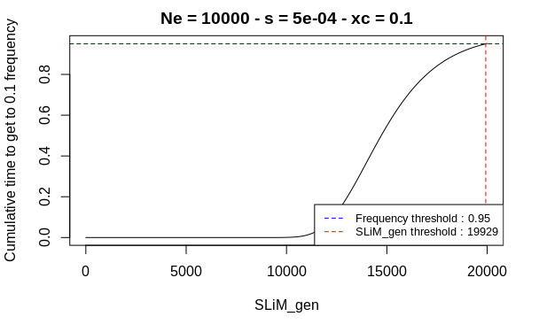

```r
abline(h=threshold, col="blue", lty="dashed")
legend("bottomright", legend=c(paste("Frequency threshold :", threshold, sep=" "), paste("SLiM_gen threshold :", first_above_threshold, sep=" ")),
       col=c("blue", "red"), lty=2, cex=0.8)
```

```r
#points(x=result_df$threshold, y=result_df$proportion)

#diff_list <- c(0, diff(probaBigTxcBelowBigT))
#plot(diff_list, type="l")

#(1-xc)/xc*s*bigT+1
```

**Run for all ResultsParam Files** **Create resultsParam tibble containing data from all log files**

```r
# Set path to log folders
resultsPath = "../../simulations/TESTING_FIX_PROBA/"

# Initialize an empty resultsLog tibble
resultsParam <- tibble()

# Loop on all directories

for (resDir in list.dirs(resultsPath)[-1])
  {
    print(resDir) # print current folder processed
    # Get list of all log files inside this specific folder
    resFiles = list.files(resDir)
    #logFiles = head(logFiles, 2) # testing : work only on first 2 files of each directory

    # Loop on all files in all directories
    for (resFile in resFiles)
    {

            if (grepl("parameters", as.character(resFile), fixed=TRUE) )
            {

      # print(paste(resDir, logFile, sep='/')) # print current file processed

      # Load file as tibble and convert columns
      # print(resFile)
      currentResFile <- as_tibble(read.table(paste(resDir, resFile, sep='/'), h=T)) %>% filter(sim_id!='sim_id')
      currentResFile <- currentResFile %>% mutate(sim_id = as.factor(sim_id), outcome = as.factor(outcome), NeA = as.integer(NeA), NeB = as.integer(NeB), s = as.double(s),
                               r = as.double(r), mu = as.double(mu), L = as.integer(L), m = as.double(m), mut_pos = as.integer(mut_pos), rise_gen = as.integer(rise_gen), fix_gen = as.integer(fix_gen),
                               SLiM_gen = as.integer(SLiM_gen), samp = as.integer(samp), mut_freq = as.double(mut_freq), run_CPU_time.s. = as.double(run_CPU_time.s.),
                               chg_r = as.double(chg_r), split_gen = as.integer(split_gen), chg_gen = as.integer(chg_gen), mig_gen = as.integer(mig_gen))

      # extract only interresting columns
      currentResFile <- currentResFile %>% filter(sim_id!='sim_id') %>% mutate(seg_time = fix_gen - rise_gen) %>% select(c(sim_id, outcome, s, mut_pos, rise_gen, fix_gen, seg_time, SLiM_gen, run_CPU_time.s.))
      #print(currentLogFile)


      # Add the currentLogFile to resultsLog using bind_rows
      resultsParam <- bind_rows(resultsParam, currentResFile)

            }
    }
}
```

```
[1] "../../simulations/TESTING_FIX_PROBA//CST-20904-16GV"
```

```
[1] "../../simulations/TESTING_FIX_PROBA//CST-20904-37Nj"
```

```
[1] "../../simulations/TESTING_FIX_PROBA//CST-20904-825e"
```

```
[1] "../../simulations/TESTING_FIX_PROBA//CST-20904-gEZf"
```

```
[1] "../../simulations/TESTING_FIX_PROBA//CST-20904-IedY"
```

```
[1] "../../simulations/TESTING_FIX_PROBA//CST-20904-JqT0"
```

```
[1] "../../simulations/TESTING_FIX_PROBA//CST-20904-lC7U"
```

[output not shown]

```
[1] "../../simulations/TESTING_FIX_PROBA//CST-20904-vUUi"
```

[output not shown]

```
[1] "../../simulations/TESTING_FIX_PROBA//CST-20904-Ykx8"
```

```
[1] "../../simulations/TESTING_FIX_PROBA//CST-20904-ytCD"
```

```
[1] "../../simulations/TESTING_FIX_PROBA//CST-20905-a8d0"
```

```
[1] "../../simulations/TESTING_FIX_PROBA//CST-20905-hZJV"
```

```
[1] "../../simulations/TESTING_FIX_PROBA//CST-20905-IRIq"
```

```
[1] "../../simulations/TESTING_FIX_PROBA//CST-20905-Tkzg"
```

```
[1] "../../simulations/TESTING_FIX_PROBA//CST-20905-Xis9"
```

```r
resultsParam
```

| sim_id | outcome | s | mut_pos | rise_gen | fix_gen | seg_time | SLiM_gen | run_CPU_time.s. |
| --- | --- | --- | --- | --- | --- | --- | --- | --- |
| CST-20904-16GV-0001 | FIXED | 0.005 | 18027 | 2 | 4281 | 4279 | 33167 | 403.50200 |
| CST-20904-16GV-0002 | FIXED | 0.005 | 1464 | 2 | 3668 | 3666 | 30358 | 527.85800 |
| CST-20904-16GV-0003 | FIXED | 0.005 | 38898 | 2 | 4746 | 4744 | 18316 | 361.01400 |
| CST-20904-16GV-0004 | FIXED | 0.005 | 29328 | 2 | 3540 | 3538 | 9005 | 182.20400 |
| CST-20904-16GV-0005 | FIXED | 0.005 | 40524 | 2 | 4585 | 4583 | 14045 | 567.34600 |
| CST-20904-16GV-0006 | SEG | 0.005 | 42940 | 2 | NA | NA | 3146 | 159.15600 |
| CST-20904-16GV-0007 | FIXED | 0.005 | 752 | 2 | 4969 | 4967 | 20890 | 970.90600 |
| CST-20904-16GV-0008 | FIXED | 0.005 | 70508 | 2 | 4257 | 4255 | 8647 | 408.20500 |
| CST-20904-16GV-0009 | FIXED | 0.005 | 31675 | 2 | 3073 | 3071 | 12964 | 625.69100 |
| CST-20904-16GV-0010 | FIXED | 0.005 | 85991 | 2 | 4127 | 4125 | 14171 | 698.64700 |

[output cut: 990 more lines]

```r
NA
NA
```

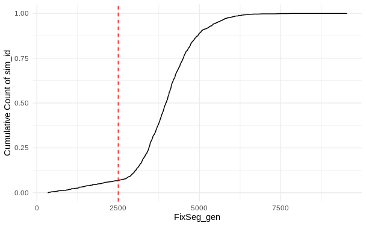

```r
your_tibble <- resultsParam %>% mutate(FixSeg_gen = case_when(outcome == "FIXED" ~ fix_gen,
                                            outcome == "SEG" ~ SLiM_gen))


# Create a cumulative sum of sim_id for increasing fix_gen
your_tibble <- your_tibble %>% select(sim_id, FixSeg_gen) %>%
  arrange(FixSeg_gen) %>%
  mutate(cumulative_count = cumsum(!is.na(FixSeg_gen)))

# Create the plot
p <- ggplot(your_tibble, aes(x = FixSeg_gen, y = cumulative_count/max(cumulative_count))) +
  geom_step() +  # Use a step plot for a cumulative effect
  labs(x = "FixSeg_gen", y = "Cumulative Count of sim_id") +
  theme_minimal()

# Add a vertical line at fix_gen = 700
p + geom_vline(xintercept = 2500, linetype = "dashed", color = "red")
```

```r
NA
NA
```

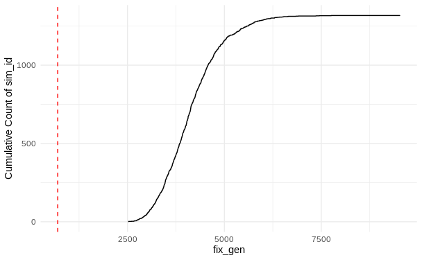

```r
# Create a cumulative sum of sim_id for increasing fix_gen
your_tibble <- resultsParam %>% select(sim_id, fix_gen) %>%
  arrange(fix_gen) %>%
  mutate(cumulative_count = cumsum(!is.na(fix_gen)))

# Create the plot
p <- ggplot(your_tibble, aes(x = fix_gen, y = cumulative_count)) +
  geom_step() +  # Use a step plot for a cumulative effect
  labs(x = "fix_gen", y = "Cumulative Count of sim_id") +
  theme_minimal()

# Add a vertical line at fix_gen = 700
p + geom_vline(xintercept = 700, linetype = "dashed", color = "red")
```

```r
as_tibble(read.table("../../simulations/TESTING_FIX_PROBA//CST-20905-Xis9/CST-20905-Xis9-0100_sweep.trees")) %>% filter(sim_id!='sim_id')
```

**TUTORIAL**